# Introduction to programming in R

## 3.3 Data frames

- A data frame is a **two-dimensional** element.
- Differently from the matrix, can contain **different data types**.
- Still, each column should be of a specific data type.
- It is generally organized by columns (that are the **variables**) and each row is an **observation** for that variable.

### 3.3.1 Create a data frame

- Generally we can create a data frame from the scratch or converting other structures (like matrices)

```r
# converting matrices
df3 <- as.data.frame(matrix3)

# creating from scratch - the data.frame() function
people <- data.frame(c("Leone","Julia","Luisa"),
                     c(31,30,28),
                     c(T,F,T))

# let's print in the console
people

# let's check for the mode of the different columns
mode(people[,1])
mode(people[,2])
mode(people[,3])

# we can add column names to the dataframe
# column names are really important for dataframes
colnames(people) <- c("name","age","italian")

# we can also add rownames, but being observation these are not really needed
rownames(people) <- c("PhD_student1","PhD_student2","PhD_student3")

# generally, column names are already added when creating the dataframe - without
#column names a data frame is "meaningless", because we do not knowthe variables
people <- data.frame(name=c("Leone","Julia","Luisa"),
                     age=c(31,30,28),
                     italian=c(T,F,T))

# we can agan add the rownames - not something we do often
rownames(people) <- c("PhD_student1","PhD_student2","PhD_student3")
```

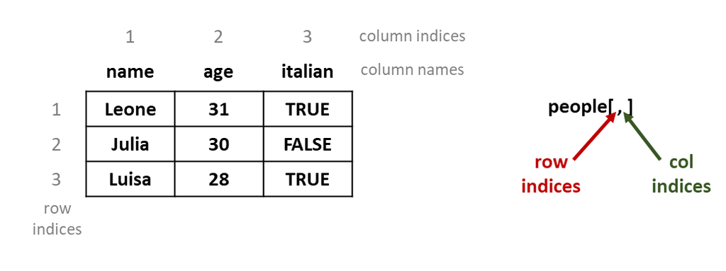

- We can access the elements in the datframe with their **indices** or with their **colnames/rownames**

```r
# these two are the same
people[,1]
people[,"name"]

people[2,2]
people["PhD_student2","age"]
```

- **Important**: for data frames, we can retrieve columns using the **dollar symbol**

```r
# these two are the same
people[,"name"]
people$name

# we can even create a new column using the dollar symbol
people$beach_volley <- c(F,T,T)
people
```

### 3.3.2 Data frame manipulation

- We manipulate data frame as if they were **vectors but in two dimensions**!

```r
# these command all output the same
people[people[,2]>=30,]
people[people[,"age"]>=30,]
people[people$age>=30,] # BEST OPTION! We prefer to use the dollar with data frames

# let's see it line by line to understand what we are doing
# 1. Extract the column with the $ sign
people$age

# 2. check for your condition of interest (i.e. age >= 30)
people$age >= 30

# subset the data frame to select only the rows that fulfill the condition
people[people$age >= 30,]
```

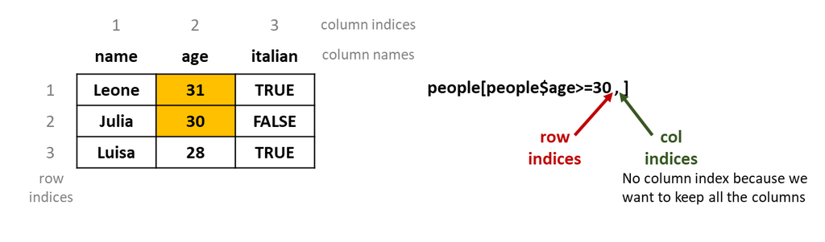

- Of course, we can select for multiple criterias

```r
# select the people that have more or equal than 30 yo and that are not from Italy
people[people$age >= 30 & people$italian==FALSE,]
# select the people that are less than 30 yo or that paly beachvolley
people[people$age < 30 | people$beach_volley==TRUE,]
```

#### 3.3.2.1 Ultra-quick HANDS-ON

- What is the age of the italian beach-volleyball player? No manual counting, let’s store the output in an object called **italian_bv_age**

**Answer**

```r
# select the people that play bv and that are from Italy
italian_bv <- people[people$beach_volley == TRUE & people$italian==TRUE,]
# extract the column with the age and assign
italian_bv_age <- italian_bv$age
```

### 3.3.3 Selection based on patterns

- We can also subset dataframes based on patterns

```r
# We can add a new column based on where these people are located
people$location <- c("sixth_office6","fourth_office3","fourth_office6")

# How can we select the people that work at the 4th floor
# we can select base on pattern using the grep function
# Let's see it line by line
people$location
grep(pattern = "fourth",x = people$location)
people[grep(pattern = "fourth",x = people$location),]
fourth_floor_people <- people[grep(pattern = "fourth",x = people$location),]
# grep has other interesting arguments, check n the help manual
```

# 4 Input and output

## 4.1 Write tables

We have now produced this new people data frame, and we want to save it. To save files from R to our computer, we can use the function **write.table()**. This functions has some parameters that is better to specify to get the output as we want.

```r
# Imagine we want to write an object as tab-separated
write.table(x = people, # object we want to save
            file = "people.txt", # path and name we want to assign + extension
            sep = "\t", # type of separator - in this case is tab
            col.names = T, # do we want to include the column names?
            row.names = F, # do we want to include the column names?
            quote = F) # Do we want to have character elements in quotes?

# ... and as comma-separated
write.table(x = people, # object we want to save
            file = "people.csv", # path and name we want to assign + extension
            sep = ",", # type of separator - in this case is comma
            col.names = T, # do we want to include the column names?
            row.names = F, # do we want to include the column names?
            quote = F) # Do we want to have character elements in quotes?
```

## 4.2 Read tables

Let’s pretend now our day is over and we saved our file. We close everything (empty the environment). We start working the next day, and we want to keep working on our people dataset. We can **load** it back in R.

Since now we have worked with dataframes and objects that we were creating in R. However, most of the times you will have to **“load” objects in R** (something produced by previous analysis, published data etc). To load data frames and matrix saved as csv, tsv, txt etc, we can use the **read.table()** function

```r
# to load a table, we assign it to an object
people_reload <- read.table(file = "people.txt",
                            header = T)
# what happens if we try to load the .csv without specifying the separator?
people_reload <- read.table(file = "people.csv",
                            header = T)

# if we know the type of file, better to specify the separator
people_reload <- read.table(file = "people.csv",
                            header = T,
                            sep = ",")
```

**Important message**: when we load a dataframe in R and we modify, we are not modifying the version on the computer. To save the changes we are doing we will have to write it again in the computer!

# 5 Missing values

**NA** (Not Available) is a recognizable element in R.

```r
missing_obj <- NA
missing_obj
mode(missing_obj)

mis_vec <- c(13,9,NA,8)
mode(mis_vec)

# to know which element is an NA we can use the is.na() function
is.na(mis_vec)

# try to remove the missing value from the vector mis_vec. How would you do it?
```

# 6 Summary exercise

- 1. Create the script exercise_data_frame.R and save it in your Rcourse_2024 folder.
- 2. Check your working directory, and if it is not the Rcourse_2024 folder set it there.
- 3. Let’s load the dataset we’ll work on. R already contains some dataset that you can load. For this exercise we load the **iris** dataset. This dataset contains measurement from three different iris plant species (setosa, virginica, versicolor), measuring width and length of petals and sepals.

```r
# load the iris dataset - to load it we use the function data()
data(iris)

# let's check the first columns to understand this dataset
head(iris)
```

|  | Sepal.Length | Sepal.Width | Petal.Length | Petal.Width | Species |
| --- | --- | --- | --- | --- | --- |
| 1 | 5.1 | 3.5 | 1.4 | 0.2 | setosa |
| 2 | 4.9 | 3.0 | 1.4 | 0.2 | setosa |
| 3 | 4.7 | 3.2 | 1.3 | 0.2 | setosa |
| 4 | 4.6 | 3.1 | 1.5 | 0.2 | setosa |
| 5 | 5.0 | 3.6 | 1.4 | 0.2 | setosa |
| 6 | 5.4 | 3.9 | 1.7 | 0.4 | setosa |

- 4. Calculate the **mean petal length** in the dataset.
- 5. Create a subset data frame (called **no_setosa**) that does not contain the species **setosa**.
- 6. Now subset the no_setosa dataframe keeping only flowers with a petal length > 4 and a sepal width < 3. Assign the output to an object called **selection**. How many observation are in this data frame?
- 7. How many virginica and versicolor are there in this **selection** dataset? Check the **table()** function.
- 8. Create a vector called **interesting**, storing there the two character elements “setosa” and “virginica”.
- 9. Now subset the iris dataframe, selecting only the rows for which the column **Species** is found in the interesting vector.
- 10. Save the iris dataframe to a file called iris.txt. Do it in a tab separated format, keeping the column names but not the rownames.In which folder is this file automatically saved?

**Answer**

```r
# 2. Check and change working directory
getwd()
setwd("your/path/to/working/directory")

# 4. Calculate mean of petal length
mean(iris$Petal.Length)

# 5. Data frame without setosa
no_setosa <- iris[iris$Species!="setosa",]
nrow(no_setosa) # to know the n of observations

# 6. Select for multiple conditions
selection <- no_setosa[no_setosa$Petal.Length>4&no_setosa$Sepal.Width<3,]

# 7. Counting observation in one column
table(selection$Species)
# other solution might be to subset the dataframe for our condition and count
nrow(selection[selection$Species=="virginica",])
nrow(selection[selection$Species=="versicolor",])

# 8. Create a new vector
interesting <- c("setosa","virginica")

# 9. Subset iris for common elements with the interesting vectors
subset <- iris[iris$Species%in%interesting,]

# 10. Save the iris datase
write.table(x = iris,file = "iris.txt",col.names = T,row.names = F,quote = F,sep = "\t")
```